# Modèle de probabilité de transmission : nul model (proba fixe)

Manal NHILI

# 1 Import libraries

```r
# Reporting
library(knitr) # R code chunking in documents
library(rmarkdown) # Dynamic report generation

# Visualization
library(ggplot2) # Graphing/visualization
library(DT) # Interactive HTML tables
library(gt) # Nicely formatted plain tables
library(httpgd) # HTTP graphics device

# Bayesian Modeling & MCMC
library(nimble) # Building MCMC models
library(coda) # MCMC diagnostics
library(bayesplot) # MCMC diagnostics
library(postpack) # Post-processing MCMC draws
library(loo) # Leave-one-out cross validation
library(mcmcplots) # MCMC traceplots

# Model Evaluation
library(Metrics) # Model evaluation metrics
library(ROCR) # Model performance visualization
library(caret) # Machine learning model evaluation
# Data Wrangling
library(tidyr) # Data tidying
library(dplyr) # Data manipulation
library(readxl) # Excel data I/O
```

# 2 Import data

```r
sero <- read_excel("serology_binomial_const.xlsx")

datatable(sero)
```

|  | Event | n | Positives | Negatives | Time |
| --- | --- | --- | --- | --- | --- |
| 1 | Experience_1_1_1h | 6 | 0 | 6 | 60 |
| 2 | Experience_1_2_6h | 6 | 0 | 6 | 360 |
| 3 | Experience_1_3_24h | 6 | 0 | 6 | 1440 |
| 4 | Experience_2_1_24h | 6 | 0 | 6 | 1440 |
| 5 | Experience_2_2_24h | 6 | 1 | 5 | 1440 |
| 6 | Experience_2_3_48h | 6 | 4 | 2 | 2880 |
| 7 | Experience_3_1_24h | 5 | 2 | 3 | 1440 |
| 8 | Experience_3_2_24h | 5 | 3 | 2 | 1440 |
| 9 | Experience_4_1_24h | 6 | 0 | 6 | 1440 |
| 10 | Experience_4_2_48h | 6 | 4 | 2 | 2880 |

[output cut: 6 more lines]

# 3 Model

Afin d’estimer le nombre d’animaux infectés après exposition au pathogène lors de différentes expérimentations, un modèle Bayesien a été développé avec le package NIMBLE sous R. Pour chaque expérimentation $i$, le nombre d’animaux positifs $y_i$ suit une loi binomiale de paramètres $n_i$ (nombre total d’animaux) et $P_i$ (probabilité d’avoir un certain nombre d’animaux positifs par experimentation). Cette loi binomiale modélise le nombre aléatoire de positifs parmi $n_i$ animaux pour une probabilité donnée $P_i$. Cette dernière dépend du temps d’exposition $t_i$ et d’une probabilité d’infection de base $p$ commune (fixe) à toutes les expériences. Plus précisément, $P_i = 1 - (1 - p)^{t_i}$, reflétant l’augmentation de la probabilité d’infection avec la durée d’exposition. La probabilité $p$ suit à priori une loi uniforme entre 0,0001 et 0,001. L’objectif de ce modèle est d’estimer les paramètres $p$ et donc $P_i$ à partir des données observées $y_i$ et $t_i$, permettant ainsi de quantifier la dynamique d’infection au cours du temps sur l’ensemble des expérimentations.

## 3.1 Define Nimble code

```r
ppr_code <- nimbleCode({
  # Prior : Uniforme
  p ~ dunif(0.0001, 0.001)

  # Likelihood : Bernoulli
  for (i in 1:nrow(sero)) {
    p_tot[i] <- 1 - (1 - p)^t[i]
    y[i] ~ dbinom(size = n[i], prob = p_tot[i])
  }
})
```

## 3.2 Define inits and data

```r
y <- sero$Positives
n <- sero$n
t<-sero$Time
data = list(y=y, n=n,t=t)

inits = lapply(1:5, function(i) {
  list(p = runif(1, 0.0001, 0.001))
})
```

## 3.3 Hyperparameters tuning

Tuning hyperparameters of the model by defining a grid of values and fitting the model for each combination of hyperparameters and keeping the one that gives the lowest WAIC.

```r
# Define parameter grids to search over
niter_grid = c(10000, 50000, 100000)
thin_grid = c(1, 5, 10)
burnin_grid = c(100, 500, 1000, 5000)

# Function to fit model and compute WAIC
fit_and_compare <- function(niter, thin, burnin) {

  # Fit model using MCMC
  ppr_mcmc <- nimbleMCMC(code = ppr_code,
                      data = data,
                      inits = inits,
                      thin = thin,
                      niter = niter,
                      nburnin = burnin,
                      nchains = 5,
                      monitors = list("p"),
                      setSeed = 123,
                      progressBar = TRUE,
                      samples = TRUE,
                      summary = TRUE,
                      WAIC = TRUE)

  # Compute WAIC
  waic <- ppr_mcmc$WAIC$WAIC

  # Return WAIC
  return(waic)
}
```

```r
# Vecteur pour stocker tous les WAIC
waics <- numeric(length(niter_grid)*length(thin_grid)*length(burnin_grid))

# Compteur pour index dans waics
count <- 1

# Tester toutes les combinaisons
for(niter in niter_grid) {
  for(thin in thin_grid) {
    for(burnin in burnin_grid) {

        waic <- fit_and_compare(niter, thin, burnin)

        # Stocker ce WAIC
        waics[count] <- waic
        count <- count + 1
      }
    }
  }
```

## 3.4 Getting the best combination of hyperparameters

```r
# Trouver l'index du meilleur WAIC
best <- which.min(waics)

# Extraire les meilleurs paramètres
iter_index <- ((best - 1) %/% (length(thin_grid) * length(burnin_grid))) + 1
thin_index <- ((best - 1) %/% length(burnin_grid)) %% length(thin_grid) + 1
burnin_index <- ((best - 1) %% length(burnin_grid)) + 1

best_niter <- niter_grid[iter_index]
best_thin <- thin_grid[thin_index]
best_burnin <- burnin_grid[burnin_index]


# Afficher de façon formatée
cat("Best Hyperparameters :", "\n")
cat(paste0("Niter : ", best_niter, "\n"))
cat(paste0("Thin : ", best_thin, "\n"))
cat(paste0("Burnin : ", best_burnin, "\n"))
```

## 3.5 Fitting model with best combination of hyperparameters

```r
ppr_mcmc <- nimbleMCMC(code = ppr_code,
                      data = data,
                      inits = inits,
                      thin = best_thin,
                      nburnin = best_burnin,
                      monitors = list("p"),
                      niter = best_niter,
                      nchains = 5,
                      setSeed = 123,
                      progressBar = TRUE,
                      samples = TRUE,
                      summary = TRUE,
                      WAIC = TRUE)
```

```r
#save(ppr_mcmc, inits, file = "p_samples_null_model.RData")
```

```r
load("p_samples_null_model.RData")
```

```r
theta_inits <- as.data.frame(inits)

new_names = paste0("chain_", 1:5)

# Change colnames
colnames(theta_inits) = new_names[1:5]

gt(theta_inits) %>%
  tab_header(title = "initial values for MCMC chains")
```

initial values for MCMC chains

| chain_1 | chain_2 | chain_3 | chain_4 | chain_5 |
| --- | --- | --- | --- | --- |
| 0.000834015 | 0.000949975 | 0.0004735731 | 0.0008152912 | 0.0009153164 |

```r
waic <- ppr_mcmc$WAIC$WAIC
cat(waic)
```

```
## 43.85097
```

```r
codaSamples <- post_convert(ppr_mcmc$samples)
p <- codaSamples[, "p"]
```

# 4 Visualization:

We plot the density of the posterior and the trace plot of the chains.

## 4.1 Density plot

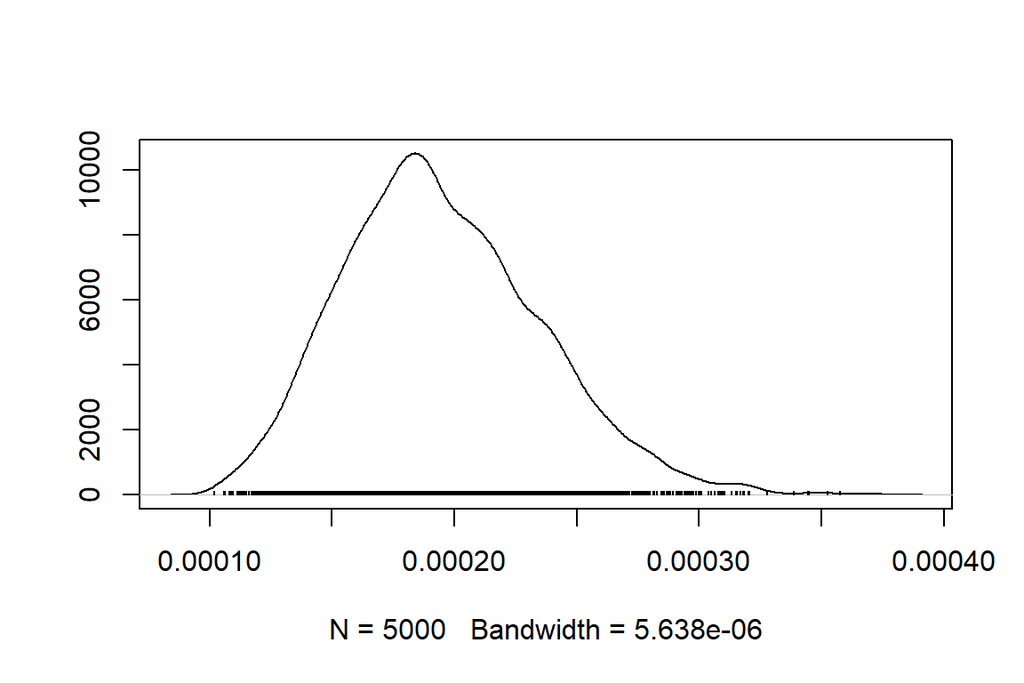

```r
densplot(p)
```

## 4.2 Trace plot

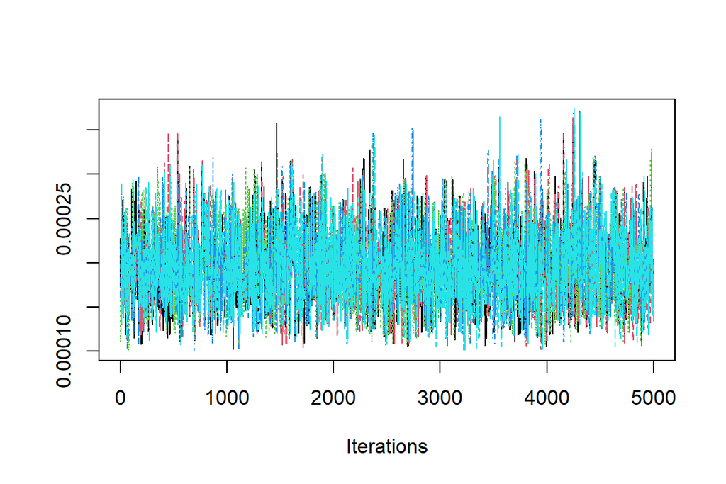

```r
traceplot(p)
```

# 5 Assessing model fit quality using WAIC

```r
waic <- ppr_mcmc$WAIC
waic
```

```
## nimbleList object of type waicNimbleList
## Field "WAIC":
## [1] 43.85097
## Field "lppd":
## [1] -20.82312
## Field "pWAIC":
## [1] 1.102362
```

# 6 Summary Statistics

```r
summary(p)
```

```
##
## Iterations = 1:5000
## Thinning interval = 1
## Number of chains = 5
## Sample size per chain = 5000
##
## 1. Empirical mean and standard deviation for each variable,
##    plus standard error of the mean:
##
##           Mean             SD       Naive SE Time-series SE
##      1.949e-04      4.031e-05      2.549e-07      5.256e-07
##
## 2. Quantiles for each variable:
##
##      2.5%       25%       50%       75%     97.5%
## 0.0001257 0.0001663 0.0001907 0.0002205 0.0002813
```

```r
loo_result <- loo(as.matrix(p))
print(loo_result)
```

```
##
## Computed from 25000 by 1 log-likelihood matrix
##
##          Estimate SE
## elpd_loo      0.0 NA
## p_loo         0.0 NA
## looic         0.0 NA
## ------
## Monte Carlo SE of elpd_loo is 0.0.
##
## All Pareto k estimates are good (k < 0.5).
## See help('pareto-k-diagnostic') for details.
```

```r
loo_result$diagnostics
```

```
## $pareto_k
## [1] -0.402586
##
## $n_eff
## [1] 25000
```

# 7 Convergence Diagnostics

## 7.1 Gelman-Rubin diagnostic

The Potential Scale Reduction Factor (PSRF), also known as the **Gelman-Rubin diagnostic** $(\hat{R})$, is a widely used metric for assessing the convergence of Markov Chain Monte Carlo (MCMC) chains in Bayesian analysis. A PSRF equal to 1 is indicative of well-converged chains. The diagnostic compares the variability within each chain to the variability between chains. A value of 1 suggests that the chains have reached a common distribution and have effectively explored the parameter space. In our analysis, the PSRF being equal to 1 provides confidence in the convergence of the MCMC chains, indicating that the chains have reached a stable and consistent estimate of the target distribution.

```r
gelman.diag(p)
```

```
## Potential scale reduction factors:
##
##      Point est. Upper C.I.
## [1,]          1          1
```

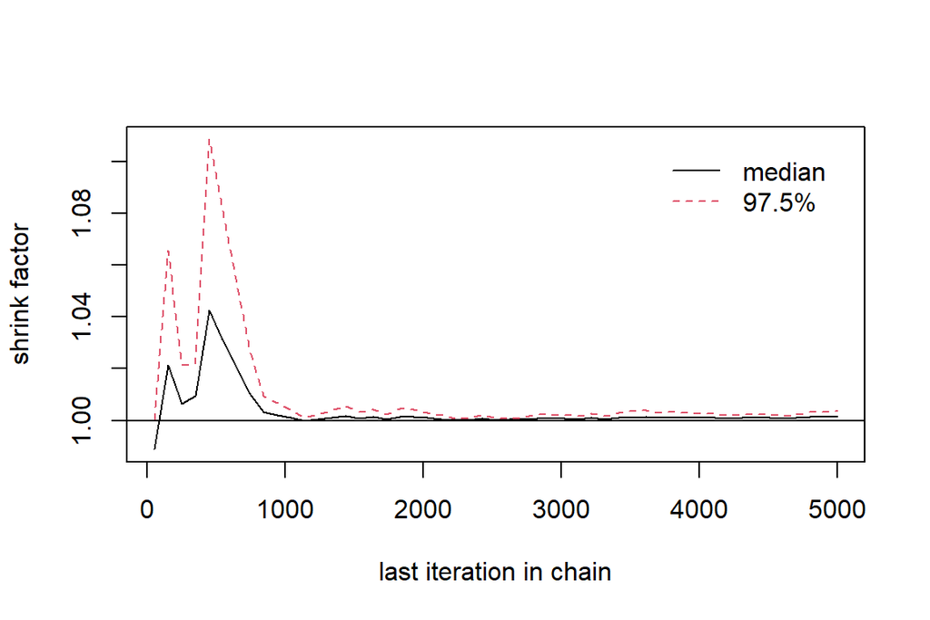

```r
gelman.plot(p)
```

## 7.2 Geweke’s convergence diagnostic

The **Geweke’s convergence diagnostic** was applied to assess the convergence of multiple MCMC chains. The diagnostic involves dividing each chain into two windows (typically the first 10% and the last 50% of iterations) and comparing the means of these segments using a z-score. A small z-score and comparable fractions in the two windows indicate convergence.

```r
geweke.diag(p)
```

```
## $chain1
##
## Fraction in 1st window = 0.1
## Fraction in 2nd window = 0.5
##
##   var1
## -2.239
##
##
## $chain2
##
## Fraction in 1st window = 0.1
## Fraction in 2nd window = 0.5
##
##  var1
## 1.017
##
##
## $chain3
##
## Fraction in 1st window = 0.1
## Fraction in 2nd window = 0.5
##
##  var1
## 1.475
##
##
## $chain4
##
## Fraction in 1st window = 0.1
## Fraction in 2nd window = 0.5
##
##   var1
## -1.222
##
##
## $chain5
##
## Fraction in 1st window = 0.1
## Fraction in 2nd window = 0.5
##
##   var1
## 0.1661
```

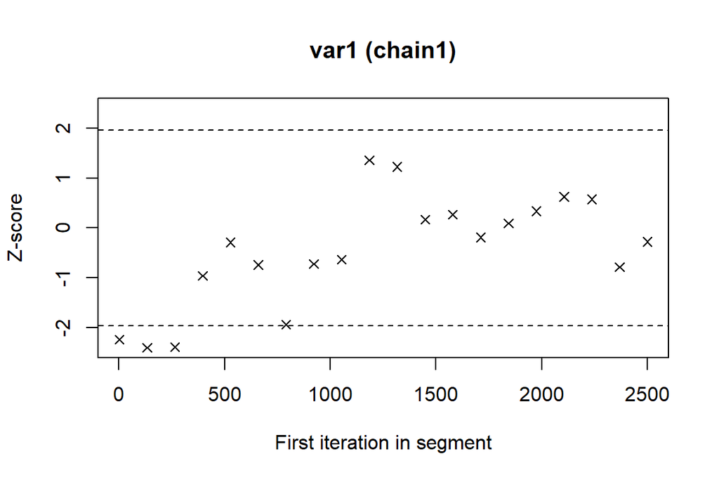

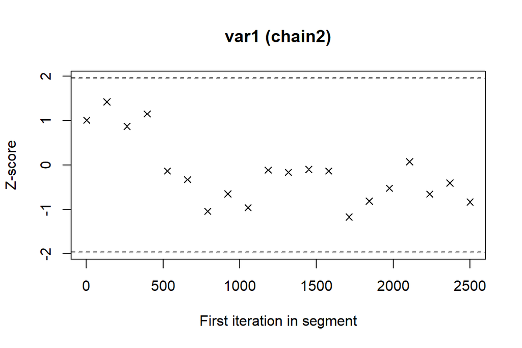

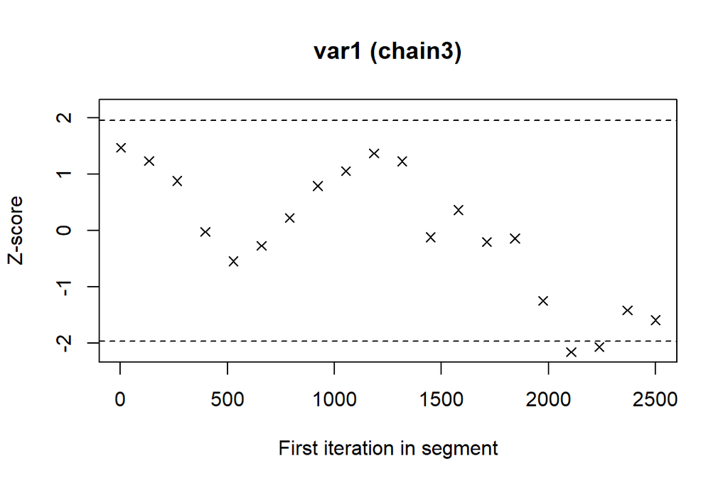

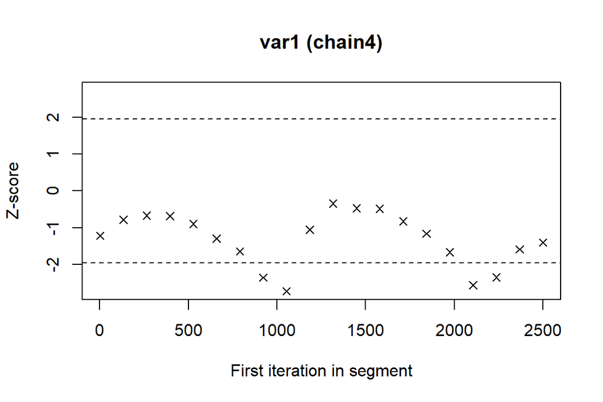

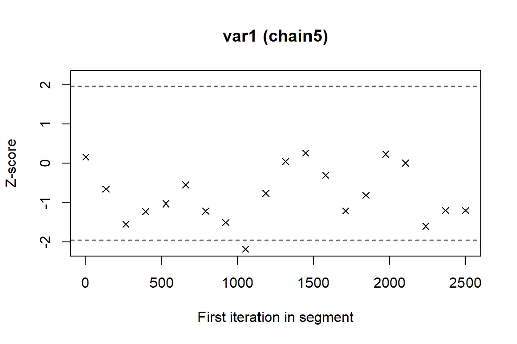

```r
geweke.plot(p)
```

# 8 Plot autocorrelation plots for all chains

Autocorrelation plots were generated to assess the correlation between successive observations in each Markov Chain Monte Carlo (MCMC) chain. The plots below illustrate the autocorrelation function (ACF) for the parameter $p$ in each chain.

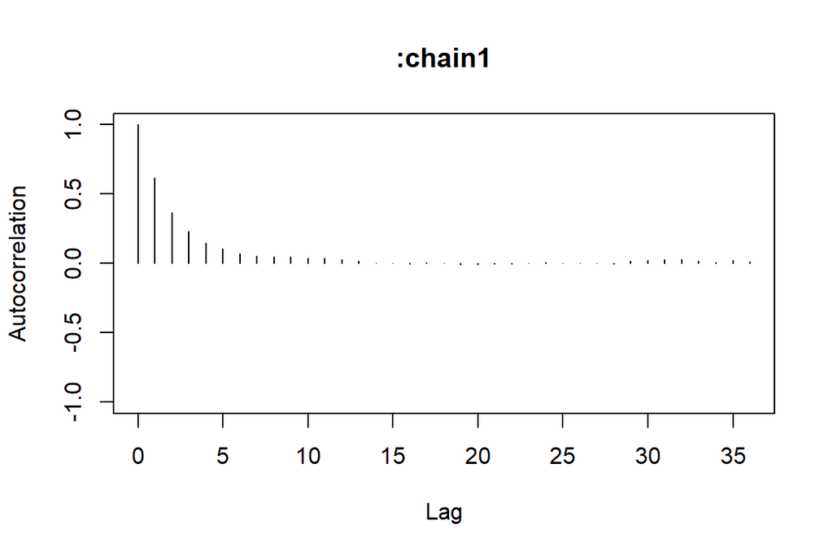

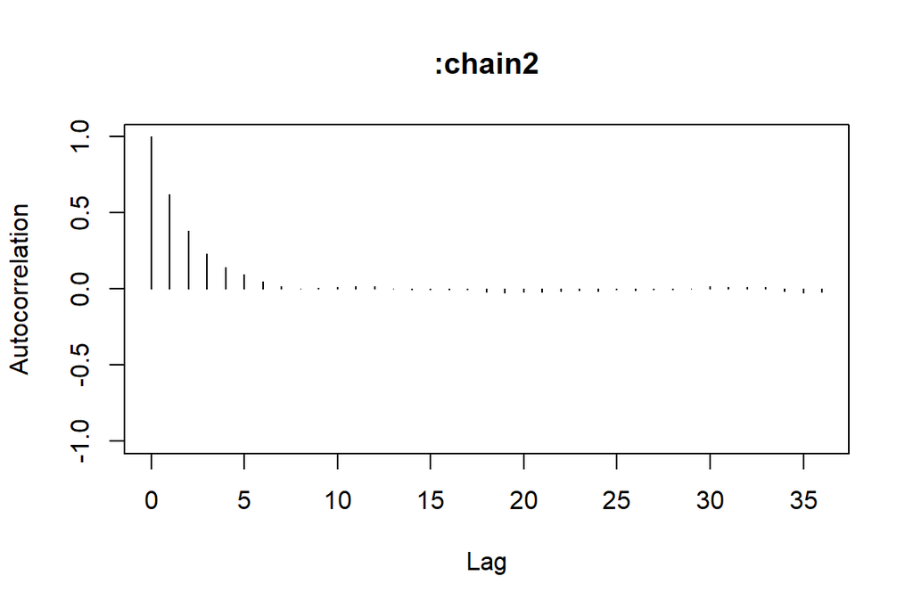

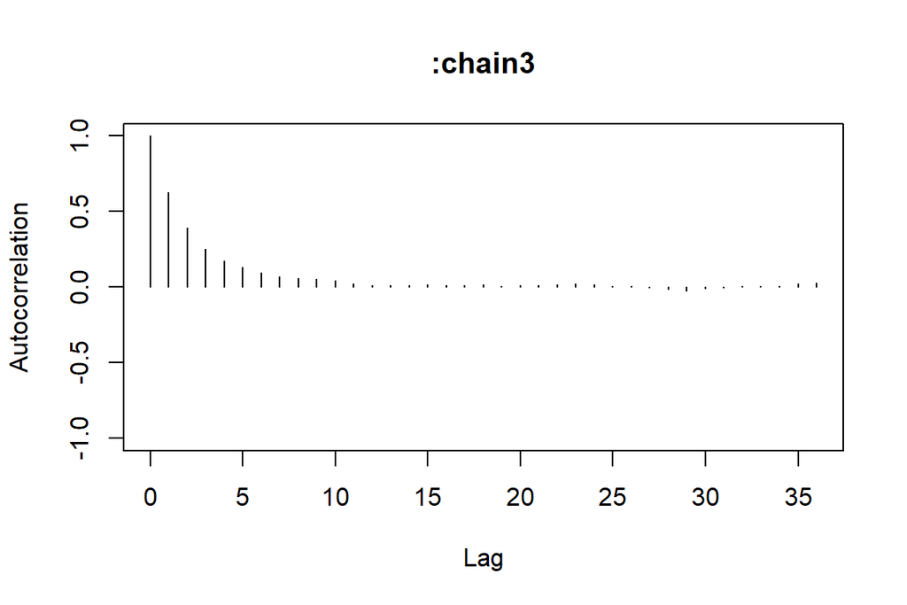

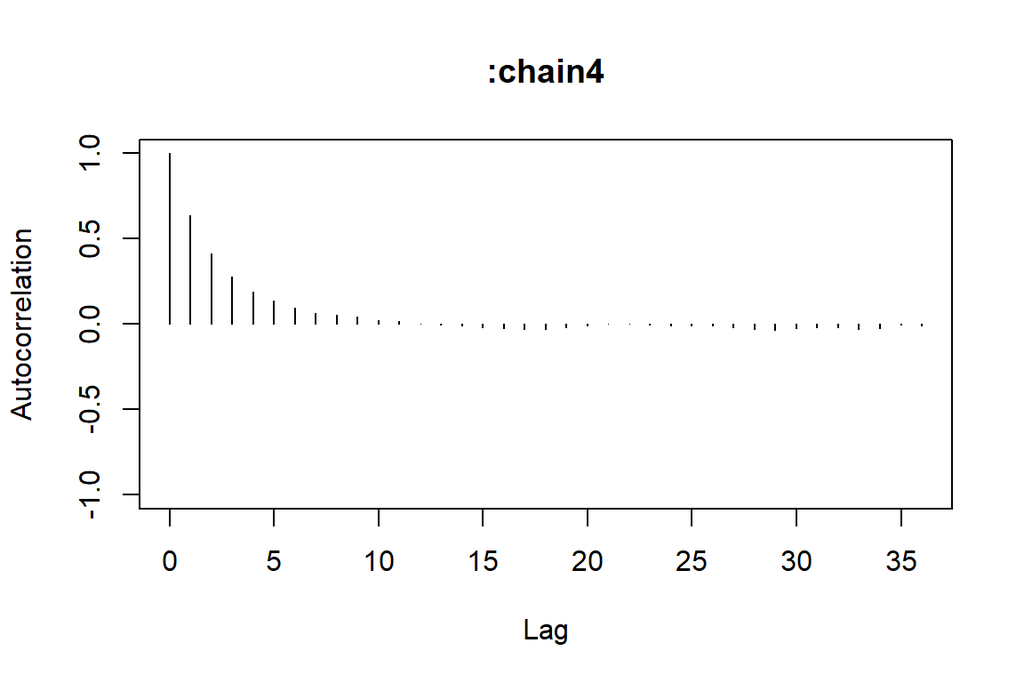

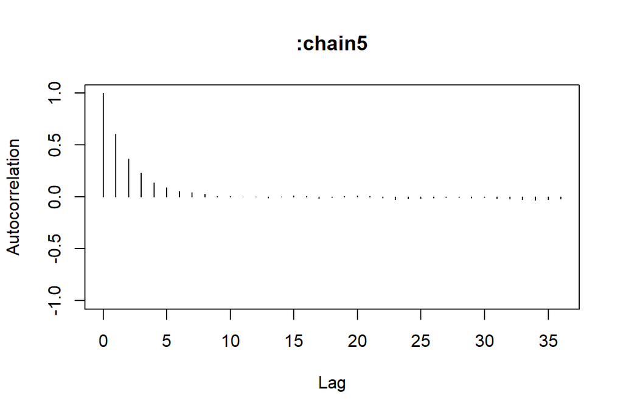

```r
autocorr.plot(p)
```

# 9 Effective sample size

The **effective sample size (ESS)** is a metric used in the context of Markov Chain Monte Carlo (MCMC) sampling to quantify the amount of information or independence captured by the samples. It provides an estimate of how many independent samples in the Markov chain are equivalent to the autocorrelated samples obtained.

$$ESS = \frac{n}{1 + 2\sum_{t=1}^{T} \rho_t}$$
In this formula:

- $ESS$ is the effective sample size.
- $n$ is the total number of samples.
- $ρ_t$ is the autocorrelation at lag $t$.
- $T$ is the maximum lag considered in the autocorrelation calculation.

An ESS of 5895.836 suggests good mixing and provides a reasonable estimate of the effective information content in our MCMC samples for the variable **`p`**.

```r
cat(effectiveSize(p))
```

```
## 5895.836
```

# 10 Posterior predictive check

## 10.1 Simulate replicated data

```r
p <- as.matrix(codaSamples)
```

## 10.2 Take a random sample of length 1000 from P estimates

```r
p_sample <- sample(p, 1000)
```

# 11 Initialisation d’une matrice pour stocker les résultats simulés

```r
N <- nrow(sero)
ncol = length(p_sample)
t <- sero$Time
n <- sero$n
```

# 12 Boucle pour simuler les résultats pour chaque valeur de p

```r
resultats_simules <- matrix(NA, nrow = N, ncol = ncol)

for (i in 1:length(p_sample)) {

  p_i <- p_sample[i]

  p_tot <- 1 - (1 - p_i)^ t

  simulations <- rbinom(N, size = n, prob = p_tot)
  resultats_simules[, i] <- simulations
}
```

```r
resultats_simules_df <- as.data.frame(resultats_simules)
colnames(resultats_simules_df) <- paste0("Sim_", 1:length(p_sample))
```

```r
datacal <- sero[,c("Event","n", "Positives")]
names(datacal) <- c("Exp", "N", "obs")
```

```r
means <- apply(resultats_simules_df, 1, mean)
print(means)
```

```
##  [1] 0.068 0.461 1.441 1.442 1.445 2.558 1.208 1.199 1.517 2.521 1.435 2.977
## [13] 1.417 2.542 0.435 0.535
```

```r
quantiles <- apply(resultats_simules_df, 1, quantile,
                   probs = c(0.025,0.25,0.5,0.75,0.975))
print(t(quantiles))
```

```
##       2.5% 25% 50% 75% 97.5%
##  [1,]    0   0 0.0   0 1.000
##  [2,]    0   0 0.0   1 2.000
##  [3,]    0   1 1.0   2 3.025
##  [4,]    0   1 1.0   2 4.000
##  [5,]    0   1 1.0   2 4.000
##  [6,]    0   2 2.0   3 5.000
##  [7,]    0   0 1.0   2 3.000
##  [8,]    0   0 1.0   2 3.000
##  [9,]    0   1 1.0   2 4.000
## [10,]    0   2 2.5   3 5.000
## [11,]    0   1 1.0   2 4.000
## [12,]    1   2 3.0   4 6.000
## [13,]    0   1 1.0   2 4.000
## [14,]    0   2 3.0   3 5.000
## [15,]    0   0 0.0   1 2.000
## [16,]    0   0 0.0   1 2.000
```

```r
res <- as.data.frame(cbind(sero$Event, t(quantiles), round(means)))

names(res)<-c("Exp","CI2.5","CI25","Median","CI75","CI97.5","Mean")

res$CI2.5 <- as.numeric(res$CI2.5)
res$CI25 <- as.numeric(res$CI25)
res$Median <- as.numeric(res$Median)
res$CI75 <- as.numeric(res$CI75)
res$CI97.5 <- as.numeric(res$CI97.5)
res$Mean <- as.numeric(res$Mean)

res
```

```
##                   Exp CI2.5 CI25 Median CI75 CI97.5 Mean
## 1   Experience_1_1_1h     0    0    0.0    0  1.000    0
## 2   Experience_1_2_6h     0    0    0.0    1  2.000    0
## 3  Experience_1_3_24h     0    1    1.0    2  3.025    1
## 4  Experience_2_1_24h     0    1    1.0    2  4.000    1
## 5  Experience_2_2_24h     0    1    1.0    2  4.000    1
## 6  Experience_2_3_48h     0    2    2.0    3  5.000    3
## 7  Experience_3_1_24h     0    0    1.0    2  3.000    1
## 8  Experience_3_2_24h     0    0    1.0    2  3.000    1
## 9  Experience_4_1_24h     0    1    1.0    2  4.000    2
## 10 Experience_4_2_48h     0    2    2.5    3  5.000    3
## 11 Experience_5_1_24h     0    1    1.0    2  4.000    1
## 12 Experience_5_2_48h     1    2    3.0    4  6.000    3
## 13 Experience_6_1_24h     0    1    1.0    2  4.000    1
## 14 Experience_6_2_48h     0    2    3.0    3  5.000    3
## 15  Experience_7_1_8h     0    0    0.0    1  2.000    0
## 16  Experience_7_2_8h     0    0    0.0    1  2.000    1
```

```r
datacal$sd<-sqrt(datacal$obs*(datacal$N-datacal$obs))
datacal
```

```
## # A tibble: 16 × 4
##    Exp                    N   obs    sd
##    <chr>              <dbl> <dbl> <dbl>
##  1 Experience_1_1_1h      6     0  0
##  2 Experience_1_2_6h      6     0  0
##  3 Experience_1_3_24h     6     0  0
##  4 Experience_2_1_24h     6     0  0
##  5 Experience_2_2_24h     6     1  2.24
##  6 Experience_2_3_48h     6     4  2.83
##  7 Experience_3_1_24h     5     2  2.45
##  8 Experience_3_2_24h     5     3  2.45
##  9 Experience_4_1_24h     6     0  0
## 10 Experience_4_2_48h     6     4  2.83
## 11 Experience_5_1_24h     6     0  0
## 12 Experience_5_2_48h     7     3  3.46
## 13 Experience_6_1_24h     6     1  2.24
## 14 Experience_6_2_48h     6     3  3
## 15 Experience_7_1_8h      5     1  2
## 16 Experience_7_2_8h      6     0  0
```

# 13 Comparison plot between predictions and real observations

## 13.1 Mean case

```
## `geom_line()`: Each group consists of only one observation.
## ℹ Do you need to adjust the group aesthetic?
```

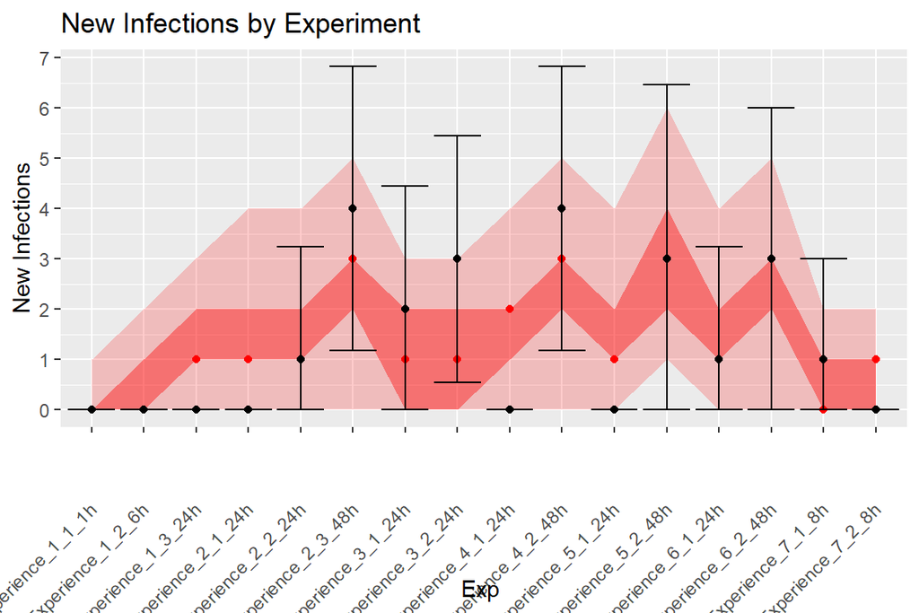

```r
p2<-ggplot(data=res,aes(x=Exp))
p2<-p2+geom_line(aes(y=Mean),col="red")+geom_point(aes(y=Mean),col="red")
p2<-p2+labs(title="New Infections by Experiment")+xlab("Exp ")
p2<-p2+geom_ribbon(aes(ymin=CI2.5,ymax=CI97.5,group=1),fill="red",alpha=0.2)
p2<-p2+geom_ribbon(aes(ymin=CI25,ymax=CI75,group=1),fill="red",alpha=0.4)
p2<-p2+geom_point(data=datacal,aes(x=Exp,y=obs))
p2<-p2+geom_errorbar(data=datacal,aes(x=Exp,ymin=ifelse(obs-sd<0,0,obs-sd),ymax=obs+sd))
p2<-p2+ylim(0,10)+scale_y_continuous(name ="New Infections", breaks=c(0,1,2,3,4,5,6,7,8,9,10))+ theme(axis.text.x = element_text(angle = 45, vjust = 0.5, hjust=1))
p2<-p2+guides(fill="none")
p2
```

## 13.2 Median case

```
## `geom_line()`: Each group consists of only one observation.
## ℹ Do you need to adjust the group aesthetic?
```

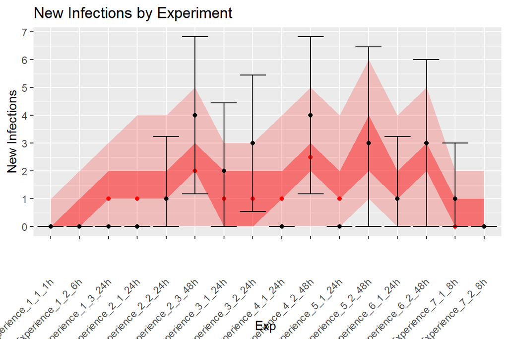

```r
p2<-ggplot(data=res,aes(x=Exp))
p2<-p2+geom_line(aes(y=Median),col="red")+geom_point(aes(y=Median),col="red")
p2<-p2+labs(title="New Infections by Experiment")+xlab("Exp ")
p2<-p2+geom_ribbon(aes(ymin=CI2.5,ymax=CI97.5,group=1),fill="red",alpha=0.2)
p2<-p2+geom_ribbon(aes(ymin=CI25,ymax=CI75,group=1),fill="red",alpha=0.4)
p2<-p2+geom_point(data=datacal,aes(x=Exp,y=obs))
p2<-p2+geom_errorbar(data=datacal,aes(x=Exp,ymin=ifelse(obs-sd<0,0,obs-sd),ymax=obs+sd))
p2<-p2+ylim(0,10)+scale_y_continuous(name ="New Infections", breaks=c(0,1,2,3,4,5,6,7,8,9,10))+ theme(axis.text.x = element_text(angle = 45, vjust = 0.5, hjust=1))
p2<-p2+guides(fill="none")
p2
```